# Pandas Series

Import Necessary Libraries

Pandas is a software library written for the Python programming language for data manipulation and analysis. In particular, it offers data structures and operations for manipulating numerical tables and time series

NumPy is an extension to the Python programming language, adding support for large, multi-dimensional arrays and matrices, along with a large library of high-level mathematical functions to operate on these arrays.

Matplotlib is a plotting library for the Python programming language and its numerical mathematics extension NumPy. There is also a procedural "pylab" interface based on a state machine (like OpenGL), designed to closely resemble that of MATLAB. Pandas makes use of matplotlib.

# 1. How to import libraries

```python
import pandas as pd
import numpy as np
import matplotlib.pyplot as plt
```

By default I always call pandas: pd, numpy: np and matplotlib.pyplot: plt

A good practice, with Ipython would be to include, right after the import of librairies an inline caller.

```python
import pandas as pd
import numpy as np
import matplotlib as mpl
import matplotlib.pyplot as plt
%matplotlib inline
mpl.rcParams["figure.figsize"] = (14, 10)
```

# 2. Verifying you have the right version of pandas

Python libraries are often updated. So regularly test for your version of the main librairies you are using.

```python
pd.__version__,np.__version__
```

```
(u'0.18.0', '1.10.0')
```

If your version is older, you can directly update it using Terminal:

conda update pandas

conda update matplotlib

conda update numpy

Once you did it, check your versions again

```python
pd.__version__,np.__version__
```

```
(u'0.18.0', '1.10.0')
```

# 3. Working with real data

a. Import Data

There is multiple options in Pandas to import data. You could import different file format:

```
- csv
- excel
- json
- pickle
- sql
- ....
```

First define the path to a folder in your directory

```python
Path_CO2 = '/Users/paulgauthier/Documents/Postdoc/PUPC/Princetonpy/CO2.csv'
Path_H2O = '/Users/paulgauthier/Documents/Postdoc/PUPC/Princetonpy/H2O.csv'
Path_RaspPi = '/Users/paulgauthier/Documents/Postdoc/PUPC/Princetonpy/RaspPi.csv'
Path_O2 = '/Users/paulgauthier/Documents/Postdoc/PUPC/Princetonpy/O2.csv'
```

Now, import the data using the path you just created

```python
CO2 = pd.read_csv(Path_CO2)
Water = pd.read_csv(Path_H2O)
RaspPi = pd.read_csv(Path_RaspPi)
O2 = pd.read_csv(Path_O2)
```

You now have 4 dataframes containing the data from 4 csv files

You can do the same with Excel files

```python
Path_CO2_xls = '/Users/paulgauthier/Documents/Postdoc/PUPC/Princetonpy/CO2.xlsx'
CO2_xls = pd.read_excel(Path_CO2_xls)
```

Both dataframe should be exactly similar. We can test the Dimension of the DataFrame using the attribute "shape"

```python
CO2.shape
```

```
(891, 7)
```

Compare the shape of the 2 dataframe. If they have the same shape then, equality should return True

```python
CO2.shape == CO2_xls.shape
```

```
True
```

Show how the dataframe looks like by calling DataFrame name

```python
CO2=pd.read_csv(Path_CO2)
CO2.columns
```

```
Index([u'gmtime', u'EPOCH_TIME', u'Conditions', u'Species', u'12CO2', u'13CO2',
       u'Delta_Raw'],
      dtype='object')
```

```python
CO2.columns=[CO2.loc[0].values]
CO2.columns
```

```
Index([ 41695.37061,   1393336413, u'Stability',  u'Xanthium',  419.0879284,
        4.707806238, -10.62752774],
      dtype='object')
```

Sometime you will find that this table is invasive and you would prefer to have a shorter version of it. Pandas has a serie of options that you could use to customize what is displayed:

```
- max_rows
- max_columns
- width
- precision
- ....
```

I always think that 10 rows are enough for the global view.

```python
pd.options.display.max_rows = 10
```

Let's try again!

```python
CO2
```

|  | gmtime | EPOCH_TIME | Conditions | Species | 12CO2 | 13CO2 | Delta_Raw |
| --- | --- | --- | --- | --- | --- | --- | --- |
| 0 | 41695.37061 | 1393336413 | Stability | Xanthium | 419.087928 | 4.707806 | -10.627528 |
| 1 | 41695.37113 | 1393336441 | Stability | Xanthium | 419.097669 | 4.705214 | -10.946173 |
| 2 | 41695.37164 | 1393336497 | Stability | Xanthium | 418.742995 | 4.707043 | -10.010987 |
| 3 | 41695.37216 | 1393336553 | Stability | Xanthium | 418.511088 | 4.701826 | -10.610874 |
| 4 | 41695.37267 | 1393336580 | Stability | Xanthium | 418.384253 | 4.699435 | -10.708263 |
| ... | ... | ... | ... | ... | ... | ... | ... |
| 886 | 41695.84775 | 1393377633 | 28 | Xanthium | 418.873640 | 4.706932 | -10.153910 |
| 887 | 41695.84822 | 1393377660 | 28 | Xanthium | 418.817308 | 4.710468 | -9.312446 |
| 888 | 41695.84869 | 1393377716 | 28 | Xanthium | 418.794454 | 4.707813 | -9.857508 |
| 889 | 41695.84916 | 1393377743 | 28 | Xanthium | 418.925316 | 4.706894 | -10.585101 |
| 890 | 41695.84963 | 1393377799 | 28 | Xanthium | 418.912498 | 4.711570 | -9.324520 |

891 rows × 7 columns

You now have a smaller view of you table and you start playing with your data.

We imported multiple csv files, let's look what they are. But first you need to remember the name of the variables you created. To do so, the functions whos and who are very useful:

```
- "who" give you a list of active variables
- "whos" gives you details on the variables
```

```python
who
```

```
CO2	 CO2_xls	 Data_CO2	 FileCO2	 O2	 Path_CO2	 Path_CO2_xls	 Path_H2O	 Path_O2
Path_RaspPi	 RaspPi	 Water	 df	 mpl	 np	 os	 path_CO2	 pd
plt
```

```python
whos
```

```
Variable       Type         Data/Info
-------------------------------------
CO2            DataFrame              gmtime  EPOCH_T<...>n\n[891 rows x 7 columns]
CO2_xls        DataFrame               gmtime    EPOC<...>n\n[891 rows x 7 columns]
Data_CO2       DataFrame                             <...>[52237 rows x 30 columns]
FileCO2        str          CFFDS2010-20150628-203257Z-DataLog_User.dat
O2             DataFrame              gmtime  EPOCH_T<...>n\n[891 rows x 6 columns]
Path_CO2       str          /Users/paulgauthier/Docum<...>/PUPC/Princetonpy/CO2.csv
Path_CO2_xls   str          /Users/paulgauthier/Docum<...>PUPC/Princetonpy/CO2.xlsx
Path_H2O       str          /Users/paulgauthier/Docum<...>/PUPC/Princetonpy/H2O.csv
Path_O2        str          /Users/paulgauthier/Docum<...>c/PUPC/Princetonpy/O2.csv
Path_RaspPi    str          /Users/paulgauthier/Docum<...>PC/Princetonpy/RaspPi.csv
RaspPi         DataFrame              gmtime  EPOCH_T<...>n\n[891 rows x 7 columns]
Water          DataFrame              gmtime  EPOCH_T<...>n\n[891 rows x 7 columns]
df             DataFrame                             <...>\n[965 rows x 30 columns]
mpl            module       <module 'matplotlib' from<...>matplotlib/__init__.pyc'>
np             module       <module 'numpy' from '/Us<...>ages/numpy/__init__.pyc'>
os             module       <module 'os' from '/Users<...>da/lib/python2.7/os.pyc'>
path_CO2       str          /Users/paulgauthier/Docum<...>5/Birch 21 LRC/Tree2/CO2/
pd             module       <module 'pandas' from '/U<...>ges/pandas/__init__.pyc'>
plt            module       <module 'matplotlib.pyplo<...>s/matplotlib/pyplot.pyc'>
```

You now know what are your variables, so let show them at once:

```python
CO2,O2,RaspPi,Water
```

```
(          gmtime  EPOCH_TIME Conditions   Species       12CO2     13CO2  \
 0    41695.37061  1393336413  Stability  Xanthium  419.087928  4.707806
 1    41695.37113  1393336441  Stability  Xanthium  419.097669  4.705214
 2    41695.37164  1393336497  Stability  Xanthium  418.742995  4.707043
 3    41695.37216  1393336553  Stability  Xanthium  418.511088  4.701826
 4    41695.37267  1393336580  Stability  Xanthium  418.384253  4.699435
 ..           ...         ...        ...       ...         ...       ...
 886  41695.84775  1393377633         28  Xanthium  418.873640  4.706932
 887  41695.84822  1393377660         28  Xanthium  418.817308  4.710468
 888  41695.84869  1393377716         28  Xanthium  418.794454  4.707813
 889  41695.84916  1393377743         28  Xanthium  418.925316  4.706894
 890  41695.84963  1393377799         28  Xanthium  418.912498  4.711570

      Delta_Raw
 0   -10.627528
```

[output cut: 67 more lines]

One can notice that the first column 'gmtime' is common to all variables. So let try to combine all these variable in one big dataframe based on 'gmtime'.

To do so, you have multiple options. First, Pandas is a very smart library that includes 3 amazing functions: merge, join and concatenate. We will just focus on "merge" for now.

merge(left,right,how='',on='',left_on='',right_on='',left_index='',right_index='',sort=True,suffixes, copy=True)

You can find details about each argument in Wes McKinney Book or http://pandas.pydata.org/pandas-docs/stable/merging.html

```python
#I will call this function by default A

A = pd.merge(CO2,O2, how='inner', on='gmtime')
```

Let's show what the dataframe looks like

```python
A
```

|  | gmtime | EPOCH_TIME_x | Conditions_x | Species_x | 12CO2 | 13CO2 | Delta_Raw | EPOCH_TIME_y | Conditions_y | Species_y | dO2/N2 | d18O |
| --- | --- | --- | --- | --- | --- | --- | --- | --- | --- | --- | --- | --- |
| 0 | 41695.37061 | 1393336413 | Stability | Xanthium | 419.087928 | 4.707806 | -10.627528 | 1393336413 | Stability | Xanthium | -0.506601 | -0.067217 |
| 1 | 41695.37113 | 1393336441 | Stability | Xanthium | 419.097669 | 4.705214 | -10.946173 | 1393336441 | Stability | Xanthium | -0.267160 | -0.083961 |
| 2 | 41695.37164 | 1393336497 | Stability | Xanthium | 418.742995 | 4.707043 | -10.010987 | 1393336497 | Stability | Xanthium | -0.228845 | 0.061407 |
| 3 | 41695.37216 | 1393336553 | Stability | Xanthium | 418.511088 | 4.701826 | -10.610874 | 1393336553 | Stability | Xanthium | -0.167285 | 0.220573 |
| 4 | 41695.37267 | 1393336580 | Stability | Xanthium | 418.384253 | 4.699435 | -10.708263 | 1393336580 | Stability | Xanthium | -0.127173 | 0.024999 |
| ... | ... | ... | ... | ... | ... | ... | ... | ... | ... | ... | ... | ... |
| 886 | 41695.84775 | 1393377633 | 28 | Xanthium | 418.873640 | 4.706932 | -10.153910 | 1393377633 | 28 | Xanthium | -0.074825 | 0.271343 |
| 887 | 41695.84822 | 1393377660 | 28 | Xanthium | 418.817308 | 4.710468 | -9.312446 | 1393377660 | 28 | Xanthium | -0.075662 | 0.147222 |
| 888 | 41695.84869 | 1393377716 | 28 | Xanthium | 418.794454 | 4.707813 | -9.857508 | 1393377716 | 28 | Xanthium | -0.060336 | 0.530910 |
| 889 | 41695.84916 | 1393377743 | 28 | Xanthium | 418.925316 | 4.706894 | -10.585101 | 1393377743 | 28 | Xanthium | -0.070518 | 0.313668 |
| 890 | 41695.84963 | 1393377799 | 28 | Xanthium | 418.912498 | 4.711570 | -9.324520 | 1393377799 | 28 | Xanthium | -0.066876 | 0.244234 |

891 rows × 12 columns

To avoid showing all the tabl everytime you are looking for a column title, you use the attribute columns:

```python
A.columns
```

```
Index([u'gmtime', u'EPOCH_TIME_x', u'Conditions_x', u'Species_x', u'12CO2',
       u'13CO2', u'Delta_Raw', u'EPOCH_TIME_y', u'Conditions_y', u'Species_y',
       u'dO2/N2', u'd18O'],
      dtype='object')
```

You can now remove the extra columns you don't need, using .drop()

```python
A.drop(['EPOCH_TIME_y'],axis=1,inplace=True)
A.drop(['Conditions_y'],axis=1,inplace=True)
A.drop(['Species_y'],axis=1,inplace=True)
```

```python
A
```

|  | gmtime | EPOCH_TIME_x | Conditions_x | Species_x | 12CO2 | 13CO2 | Delta_Raw | dO2/N2 | d18O |
| --- | --- | --- | --- | --- | --- | --- | --- | --- | --- |
| 0 | 41695.37061 | 1393336413 | Stability | Xanthium | 419.087928 | 4.707806 | -10.627528 | -0.506601 | -0.067217 |
| 1 | 41695.37113 | 1393336441 | Stability | Xanthium | 419.097669 | 4.705214 | -10.946173 | -0.267160 | -0.083961 |
| 2 | 41695.37164 | 1393336497 | Stability | Xanthium | 418.742995 | 4.707043 | -10.010987 | -0.228845 | 0.061407 |
| 3 | 41695.37216 | 1393336553 | Stability | Xanthium | 418.511088 | 4.701826 | -10.610874 | -0.167285 | 0.220573 |
| 4 | 41695.37267 | 1393336580 | Stability | Xanthium | 418.384253 | 4.699435 | -10.708263 | -0.127173 | 0.024999 |
| ... | ... | ... | ... | ... | ... | ... | ... | ... | ... |
| 886 | 41695.84775 | 1393377633 | 28 | Xanthium | 418.873640 | 4.706932 | -10.153910 | -0.074825 | 0.271343 |
| 887 | 41695.84822 | 1393377660 | 28 | Xanthium | 418.817308 | 4.710468 | -9.312446 | -0.075662 | 0.147222 |
| 888 | 41695.84869 | 1393377716 | 28 | Xanthium | 418.794454 | 4.707813 | -9.857508 | -0.060336 | 0.530910 |
| 889 | 41695.84916 | 1393377743 | 28 | Xanthium | 418.925316 | 4.706894 | -10.585101 | -0.070518 | 0.313668 |
| 890 | 41695.84963 | 1393377799 | 28 | Xanthium | 418.912498 | 4.711570 | -9.324520 | -0.066876 | 0.244234 |

891 rows × 9 columns

```python
B = pd.merge(A,Water,how='inner', on='gmtime')
```

```python
B
```

|  | gmtime | EPOCH_TIME_x | Conditions_x | Species_x | 12CO2 | 13CO2 | Delta_Raw | dO2/N2 | d18O | EPOCH_TIME | Conditions | Species | H2O | Delta_18_16 | Delta_D_H |
| --- | --- | --- | --- | --- | --- | --- | --- | --- | --- | --- | --- | --- | --- | --- | --- |
| 0 | 41695.37061 | 1393336413 | Stability | Xanthium | 419.087928 | 4.707806 | -10.627528 | -0.506601 | -0.067217 | 1393336413 | Stability | Xanthium | 18.304179 | 142.932962 | 51.476888 |
| 1 | 41695.37113 | 1393336441 | Stability | Xanthium | 419.097669 | 4.705214 | -10.946173 | -0.267160 | -0.083961 | 1393336441 | Stability | Xanthium | 17.564865 | 132.181044 | -126.439366 |
| 2 | 41695.37164 | 1393336497 | Stability | Xanthium | 418.742995 | 4.707043 | -10.010987 | -0.228845 | 0.061407 | 1393336497 | Stability | Xanthium | 16.798687 | 121.437411 | -71.991218 |
| 3 | 41695.37216 | 1393336553 | Stability | Xanthium | 418.511088 | 4.701826 | -10.610874 | -0.167285 | 0.220573 | 1393336553 | Stability | Xanthium | 15.970207 | 144.785544 | -15.744760 |
| 4 | 41695.37267 | 1393336580 | Stability | Xanthium | 418.384253 | 4.699435 | -10.708263 | -0.127173 | 0.024999 | 1393336580 | Stability | Xanthium | 16.096752 | 95.504243 | 30.552564 |
| ... | ... | ... | ... | ... | ... | ... | ... | ... | ... | ... | ... | ... | ... | ... | ... |
| 886 | 41695.84775 | 1393377633 | 28 | Xanthium | 418.873640 | 4.706932 | -10.153910 | -0.074825 | 0.271343 | 1393377633 | 28 | Xanthium | 6080.841143 | 7874.774110 | 124.642147 |
| 887 | 41695.84822 | 1393377660 | 28 | Xanthium | 418.817308 | 4.710468 | -9.312446 | -0.075662 | 0.147222 | 1393377660 | 28 | Xanthium | 6124.385549 | 7879.733552 | 125.940038 |
| 888 | 41695.84869 | 1393377716 | 28 | Xanthium | 418.794454 | 4.707813 | -9.857508 | -0.060336 | 0.530910 | 1393377716 | 28 | Xanthium | 6146.538170 | 7881.091023 | 126.829252 |
| 889 | 41695.84916 | 1393377743 | 28 | Xanthium | 418.925316 | 4.706894 | -10.585101 | -0.070518 | 0.313668 | 1393377743 | 28 | Xanthium | 6165.700096 | 7884.878053 | 127.173989 |
| 890 | 41695.84963 | 1393377799 | 28 | Xanthium | 418.912498 | 4.711570 | -9.324520 | -0.066876 | 0.244234 | 1393377799 | 28 | Xanthium | 6154.869221 | 7884.848328 | 127.588930 |

891 rows × 15 columns

```python
data = pd.merge(B,RaspPi,how='inner', on='gmtime')
```

```python
data
```

|  | gmtime | EPOCH_TIME_x | Conditions_x | Species_x | 12CO2 | 13CO2 | Delta_Raw | dO2/N2 | d18O | EPOCH_TIME_x | ... | Species_x | H2O | Delta_18_16 | Delta_D_H | EPOCH_TIME_y | Conditions_y | Species_y | Tleaf | Tair | Flow rate |
| --- | --- | --- | --- | --- | --- | --- | --- | --- | --- | --- | --- | --- | --- | --- | --- | --- | --- | --- | --- | --- | --- |
| 0 | 41695.37061 | 1393336413 | Stability | Xanthium | 419.087928 | 4.707806 | -10.627528 | -0.506601 | -0.067217 | 1393336413 | ... | Xanthium | 18.304179 | 142.932962 | 51.476888 | 1393336413 | Stability | Xanthium | 21.25 | 20.25 | 1.96 |
| 1 | 41695.37113 | 1393336441 | Stability | Xanthium | 419.097669 | 4.705214 | -10.946173 | -0.267160 | -0.083961 | 1393336441 | ... | Xanthium | 17.564865 | 132.181044 | -126.439366 | 1393336441 | Stability | Xanthium | 21.25 | 20.25 | 1.96 |
| 2 | 41695.37164 | 1393336497 | Stability | Xanthium | 418.742995 | 4.707043 | -10.010987 | -0.228845 | 0.061407 | 1393336497 | ... | Xanthium | 16.798687 | 121.437411 | -71.991218 | 1393336497 | Stability | Xanthium | 21.25 | 20.25 | 1.96 |
| 3 | 41695.37216 | 1393336553 | Stability | Xanthium | 418.511088 | 4.701826 | -10.610874 | -0.167285 | 0.220573 | 1393336553 | ... | Xanthium | 15.970207 | 144.785544 | -15.744760 | 1393336553 | Stability | Xanthium | 21.25 | 20.25 | 1.96 |
| 4 | 41695.37267 | 1393336580 | Stability | Xanthium | 418.384253 | 4.699435 | -10.708263 | -0.127173 | 0.024999 | 1393336580 | ... | Xanthium | 16.096752 | 95.504243 | 30.552564 | 1393336580 | Stability | Xanthium | 21.25 | 20.25 | 1.96 |
| ... | ... | ... | ... | ... | ... | ... | ... | ... | ... | ... | ... | ... | ... | ... | ... | ... | ... | ... | ... | ... | ... |
| 886 | 41695.84775 | 1393377633 | 28 | Xanthium | 418.873640 | 4.706932 | -10.153910 | -0.074825 | 0.271343 | 1393377633 | ... | Xanthium | 6080.841143 | 7874.774110 | 124.642147 | 1393377633 | 28 | Xanthium | 19.25 | 18.50 | 2.74 |
| 887 | 41695.84822 | 1393377660 | 28 | Xanthium | 418.817308 | 4.710468 | -9.312446 | -0.075662 | 0.147222 | 1393377660 | ... | Xanthium | 6124.385549 | 7879.733552 | 125.940038 | 1393377660 | 28 | Xanthium | 19.50 | 18.50 | 2.48 |
| 888 | 41695.84869 | 1393377716 | 28 | Xanthium | 418.794454 | 4.707813 | -9.857508 | -0.060336 | 0.530910 | 1393377716 | ... | Xanthium | 6146.538170 | 7881.091023 | 126.829252 | 1393377716 | 28 | Xanthium | 19.25 | 18.50 | 2.48 |
| 889 | 41695.84916 | 1393377743 | 28 | Xanthium | 418.925316 | 4.706894 | -10.585101 | -0.070518 | 0.313668 | 1393377743 | ... | Xanthium | 6165.700096 | 7884.878053 | 127.173989 | 1393377743 | 28 | Xanthium | 19.25 | 18.75 | 2.49 |
| 890 | 41695.84963 | 1393377799 | 28 | Xanthium | 418.912498 | 4.711570 | -9.324520 | -0.066876 | 0.244234 | 1393377799 | ... | Xanthium | 6154.869221 | 7884.848328 | 127.588930 | 1393377799 | 28 | Xanthium | 19.25 | 18.50 | 2.53 |

891 rows × 21 columns

```python
data.columns
```

```
Index([u'gmtime', u'EPOCH_TIME_x', u'Conditions_x', u'Species_x', u'12CO2',
       u'13CO2', u'Delta_Raw', u'dO2/N2', u'd18O', u'EPOCH_TIME_x',
       u'Conditions_x', u'Species_x', u'H2O', u'Delta_18_16', u'Delta_D_H',
       u'EPOCH_TIME_y', u'Conditions_y', u'Species_y', u'Tleaf', u'Tair',
       u'Flow rate'],
      dtype='object')
```

But Pandas is very smart and is able to figure out how to merge you data if your data contain similar columns. Here EPOCH_TIME,Conditions, Species and gmtime

```python
A1 = pd.merge(CO2,O2)
```

```python
A1
```

|  | gmtime | EPOCH_TIME | Conditions | Species | 12CO2 | 13CO2 | Delta_Raw | dO2/N2 | d18O |
| --- | --- | --- | --- | --- | --- | --- | --- | --- | --- |
| 0 | 41695.37061 | 1393336413 | Stability | Xanthium | 419.087928 | 4.707806 | -10.627528 | -0.506601 | -0.067217 |
| 1 | 41695.37113 | 1393336441 | Stability | Xanthium | 419.097669 | 4.705214 | -10.946173 | -0.267160 | -0.083961 |
| 2 | 41695.37164 | 1393336497 | Stability | Xanthium | 418.742995 | 4.707043 | -10.010987 | -0.228845 | 0.061407 |
| 3 | 41695.37216 | 1393336553 | Stability | Xanthium | 418.511088 | 4.701826 | -10.610874 | -0.167285 | 0.220573 |
| 4 | 41695.37267 | 1393336580 | Stability | Xanthium | 418.384253 | 4.699435 | -10.708263 | -0.127173 | 0.024999 |
| ... | ... | ... | ... | ... | ... | ... | ... | ... | ... |
| 886 | 41695.84775 | 1393377633 | 28 | Xanthium | 418.873640 | 4.706932 | -10.153910 | -0.074825 | 0.271343 |
| 887 | 41695.84822 | 1393377660 | 28 | Xanthium | 418.817308 | 4.710468 | -9.312446 | -0.075662 | 0.147222 |
| 888 | 41695.84869 | 1393377716 | 28 | Xanthium | 418.794454 | 4.707813 | -9.857508 | -0.060336 | 0.530910 |
| 889 | 41695.84916 | 1393377743 | 28 | Xanthium | 418.925316 | 4.706894 | -10.585101 | -0.070518 | 0.313668 |
| 890 | 41695.84963 | 1393377799 | 28 | Xanthium | 418.912498 | 4.711570 | -9.324520 | -0.066876 | 0.244234 |

891 rows × 9 columns

```python
B1 = pd.merge(A1,Water)
```

```python
B1
```

|  | gmtime | EPOCH_TIME | Conditions | Species | 12CO2 | 13CO2 | Delta_Raw | dO2/N2 | d18O | H2O | Delta_18_16 | Delta_D_H |
| --- | --- | --- | --- | --- | --- | --- | --- | --- | --- | --- | --- | --- |
| 0 | 41695.37061 | 1393336413 | Stability | Xanthium | 419.087928 | 4.707806 | -10.627528 | -0.506601 | -0.067217 | 18.304179 | 142.932962 | 51.476888 |
| 1 | 41695.37113 | 1393336441 | Stability | Xanthium | 419.097669 | 4.705214 | -10.946173 | -0.267160 | -0.083961 | 17.564865 | 132.181044 | -126.439366 |
| 2 | 41695.37164 | 1393336497 | Stability | Xanthium | 418.742995 | 4.707043 | -10.010987 | -0.228845 | 0.061407 | 16.798687 | 121.437411 | -71.991218 |
| 3 | 41695.37216 | 1393336553 | Stability | Xanthium | 418.511088 | 4.701826 | -10.610874 | -0.167285 | 0.220573 | 15.970207 | 144.785544 | -15.744760 |
| 4 | 41695.37267 | 1393336580 | Stability | Xanthium | 418.384253 | 4.699435 | -10.708263 | -0.127173 | 0.024999 | 16.096752 | 95.504243 | 30.552564 |
| ... | ... | ... | ... | ... | ... | ... | ... | ... | ... | ... | ... | ... |
| 886 | 41695.84775 | 1393377633 | 28 | Xanthium | 418.873640 | 4.706932 | -10.153910 | -0.074825 | 0.271343 | 6080.841143 | 7874.774110 | 124.642147 |
| 887 | 41695.84822 | 1393377660 | 28 | Xanthium | 418.817308 | 4.710468 | -9.312446 | -0.075662 | 0.147222 | 6124.385549 | 7879.733552 | 125.940038 |
| 888 | 41695.84869 | 1393377716 | 28 | Xanthium | 418.794454 | 4.707813 | -9.857508 | -0.060336 | 0.530910 | 6146.538170 | 7881.091023 | 126.829252 |
| 889 | 41695.84916 | 1393377743 | 28 | Xanthium | 418.925316 | 4.706894 | -10.585101 | -0.070518 | 0.313668 | 6165.700096 | 7884.878053 | 127.173989 |
| 890 | 41695.84963 | 1393377799 | 28 | Xanthium | 418.912498 | 4.711570 | -9.324520 | -0.066876 | 0.244234 | 6154.869221 | 7884.848328 | 127.588930 |

891 rows × 12 columns

```python
data1 = pd.merge(B1,RaspPi)
```

```python
data1
```

|  | gmtime | EPOCH_TIME | Conditions | Species | 12CO2 | 13CO2 | Delta_Raw | dO2/N2 | d18O | H2O | Delta_18_16 | Delta_D_H | Tleaf | Tair | Flow rate |
| --- | --- | --- | --- | --- | --- | --- | --- | --- | --- | --- | --- | --- | --- | --- | --- |
| 0 | 41695.37061 | 1393336413 | Stability | Xanthium | 419.087928 | 4.707806 | -10.627528 | -0.506601 | -0.067217 | 18.304179 | 142.932962 | 51.476888 | 21.25 | 20.25 | 1.96 |
| 1 | 41695.37113 | 1393336441 | Stability | Xanthium | 419.097669 | 4.705214 | -10.946173 | -0.267160 | -0.083961 | 17.564865 | 132.181044 | -126.439366 | 21.25 | 20.25 | 1.96 |
| 2 | 41695.37164 | 1393336497 | Stability | Xanthium | 418.742995 | 4.707043 | -10.010987 | -0.228845 | 0.061407 | 16.798687 | 121.437411 | -71.991218 | 21.25 | 20.25 | 1.96 |
| 3 | 41695.37216 | 1393336553 | Stability | Xanthium | 418.511088 | 4.701826 | -10.610874 | -0.167285 | 0.220573 | 15.970207 | 144.785544 | -15.744760 | 21.25 | 20.25 | 1.96 |
| 4 | 41695.37267 | 1393336580 | Stability | Xanthium | 418.384253 | 4.699435 | -10.708263 | -0.127173 | 0.024999 | 16.096752 | 95.504243 | 30.552564 | 21.25 | 20.25 | 1.96 |
| ... | ... | ... | ... | ... | ... | ... | ... | ... | ... | ... | ... | ... | ... | ... | ... |
| 886 | 41695.84775 | 1393377633 | 28 | Xanthium | 418.873640 | 4.706932 | -10.153910 | -0.074825 | 0.271343 | 6080.841143 | 7874.774110 | 124.642147 | 19.25 | 18.50 | 2.74 |
| 887 | 41695.84822 | 1393377660 | 28 | Xanthium | 418.817308 | 4.710468 | -9.312446 | -0.075662 | 0.147222 | 6124.385549 | 7879.733552 | 125.940038 | 19.50 | 18.50 | 2.48 |
| 888 | 41695.84869 | 1393377716 | 28 | Xanthium | 418.794454 | 4.707813 | -9.857508 | -0.060336 | 0.530910 | 6146.538170 | 7881.091023 | 126.829252 | 19.25 | 18.50 | 2.48 |
| 889 | 41695.84916 | 1393377743 | 28 | Xanthium | 418.925316 | 4.706894 | -10.585101 | -0.070518 | 0.313668 | 6165.700096 | 7884.878053 | 127.173989 | 19.25 | 18.75 | 2.49 |
| 890 | 41695.84963 | 1393377799 | 28 | Xanthium | 418.912498 | 4.711570 | -9.324520 | -0.066876 | 0.244234 | 6154.869221 | 7884.848328 | 127.588930 | 19.25 | 18.50 | 2.53 |

891 rows × 15 columns

You can also write this is one line

```python
data2 = pd.merge(pd.merge(pd.merge(CO2,O2),Water),RaspPi)
```

```python
data2
```

|  | gmtime | EPOCH_TIME | Conditions | Species | 12CO2 | 13CO2 | Delta_Raw | dO2/N2 | d18O | H2O | Delta_18_16 | Delta_D_H | Tleaf | Tair | Flow rate |
| --- | --- | --- | --- | --- | --- | --- | --- | --- | --- | --- | --- | --- | --- | --- | --- |
| 0 | 41695.37061 | 1393336413 | Stability | Xanthium | 419.087928 | 4.707806 | -10.627528 | -0.506601 | -0.067217 | 18.304179 | 142.932962 | 51.476888 | 21.25 | 20.25 | 1.96 |
| 1 | 41695.37113 | 1393336441 | Stability | Xanthium | 419.097669 | 4.705214 | -10.946173 | -0.267160 | -0.083961 | 17.564865 | 132.181044 | -126.439366 | 21.25 | 20.25 | 1.96 |
| 2 | 41695.37164 | 1393336497 | Stability | Xanthium | 418.742995 | 4.707043 | -10.010987 | -0.228845 | 0.061407 | 16.798687 | 121.437411 | -71.991218 | 21.25 | 20.25 | 1.96 |
| 3 | 41695.37216 | 1393336553 | Stability | Xanthium | 418.511088 | 4.701826 | -10.610874 | -0.167285 | 0.220573 | 15.970207 | 144.785544 | -15.744760 | 21.25 | 20.25 | 1.96 |
| 4 | 41695.37267 | 1393336580 | Stability | Xanthium | 418.384253 | 4.699435 | -10.708263 | -0.127173 | 0.024999 | 16.096752 | 95.504243 | 30.552564 | 21.25 | 20.25 | 1.96 |
| ... | ... | ... | ... | ... | ... | ... | ... | ... | ... | ... | ... | ... | ... | ... | ... |
| 886 | 41695.84775 | 1393377633 | 28 | Xanthium | 418.873640 | 4.706932 | -10.153910 | -0.074825 | 0.271343 | 6080.841143 | 7874.774110 | 124.642147 | 19.25 | 18.50 | 2.74 |
| 887 | 41695.84822 | 1393377660 | 28 | Xanthium | 418.817308 | 4.710468 | -9.312446 | -0.075662 | 0.147222 | 6124.385549 | 7879.733552 | 125.940038 | 19.50 | 18.50 | 2.48 |
| 888 | 41695.84869 | 1393377716 | 28 | Xanthium | 418.794454 | 4.707813 | -9.857508 | -0.060336 | 0.530910 | 6146.538170 | 7881.091023 | 126.829252 | 19.25 | 18.50 | 2.48 |
| 889 | 41695.84916 | 1393377743 | 28 | Xanthium | 418.925316 | 4.706894 | -10.585101 | -0.070518 | 0.313668 | 6165.700096 | 7884.878053 | 127.173989 | 19.25 | 18.75 | 2.49 |
| 890 | 41695.84963 | 1393377799 | 28 | Xanthium | 418.912498 | 4.711570 | -9.324520 | -0.066876 | 0.244234 | 6154.869221 | 7884.848328 | 127.588930 | 19.25 | 18.50 | 2.53 |

891 rows × 15 columns

Following are some interesting functions in Pandas:

```python
data2.tail(10).mean()
```

```
gmtime         4.169585e+04
EPOCH_TIME     1.393378e+09
12CO2          4.188142e+02
13CO2          4.708682e+00
Delta_Raw     -9.738182e+00
                   ...
Delta_18_16    7.874504e+03
Delta_D_H      1.252641e+02
Tleaf          1.940000e+01
Tair           1.865000e+01
Flow rate      2.548000e+00
dtype: float64
```

```python
pd.options.display.max_rows=20
```

```python
data2.mean
```

```
<bound method DataFrame.mean of           gmtime  EPOCH_TIME Conditions   Species       12CO2     13CO2  \
0    41695.37061  1393336413  Stability  Xanthium  419.087928  4.707806
1    41695.37113  1393336441  Stability  Xanthium  419.097669  4.705214
2    41695.37164  1393336497  Stability  Xanthium  418.742995  4.707043
3    41695.37216  1393336553  Stability  Xanthium  418.511088  4.701826
4    41695.37267  1393336580  Stability  Xanthium  418.384253  4.699435
5    41695.37319  1393336636  Stability  Xanthium  418.370112  4.700013
6    41695.37370  1393336664  Stability  Xanthium  418.303371  4.700067
7    41695.37422  1393336720  Stability  Xanthium  418.300288  4.700902
8    41695.37473  1393336776  Stability  Xanthium  418.387038  4.701533
9    41695.37525  1393336803  Stability  Xanthium  418.484204  4.700034
..           ...         ...        ...       ...         ...       ...
881  41695.84540  1393377438         28  Xanthium  418.748610  4.707859
882  41695.84587  1393377465         28  Xanthium  418.763545  4.708985
883  41695.84634  1393377521         28  Xanthium  418.803603  4.711569
```

[output cut: 55 more lines]

```python
data2.std()
```

```
gmtime             0.135423
EPOCH_TIME     11700.606807
12CO2             34.224812
13CO2              0.378836
Delta_Raw          1.458688
dO2/N2             0.166391
d18O               2.289179
H2O             4891.261397
Delta_18_16     2691.446749
Delta_D_H         80.448794
Tleaf              1.487626
Tair               1.094692
Flow rate          0.331625
dtype: float64
```

```python
data2.max()
```

```
gmtime            41695.8
EPOCH_TIME     1393377799
Conditions      Stability
Species          Xanthium
12CO2             433.435
13CO2             4.86858
Delta_Raw        -5.27089
dO2/N2           0.389468
d18O              6.63759
H2O                 14148
Delta_18_16       7884.88
Delta_D_H         446.097
Tleaf                  24
Tair                21.25
Flow rate            2.94
dtype: object
```

```python
data2.min()
```

```
gmtime            41695.4
EPOCH_TIME     1393336413
Conditions            107
Species          Xanthium
12CO2             336.086
13CO2              3.7917
Delta_Raw        -11.5253
dO2/N2          -0.506601
d18O            -0.239792
H2O               5.35646
Delta_18_16       32.5315
Delta_D_H        -524.189
Tleaf                17.5
Tair                16.25
Flow rate            1.15
dtype: object
```

You can also obtain all of this statistical parameters by using describe()

```python
data2.describe()
```

|  | gmtime | EPOCH_TIME | 12CO2 | 13CO2 | Delta_Raw | dO2/N2 | d18O | H2O | Delta_18_16 | Delta_D_H | Tleaf | Tair | Flow rate |
| --- | --- | --- | --- | --- | --- | --- | --- | --- | --- | --- | --- | --- | --- |
| count | 891.000000 | 8.910000e+02 | 891.000000 | 891.000000 | 891.000000 | 877.000000 | 877.000000 | 891.000000 | 891.000000 | 891.000000 | 891.000000 | 891.000000 | 891.000000 |
| mean | 41695.620226 | 1.393358e+09 | 370.602244 | 4.174146 | -7.944638 | 0.168258 | 2.267445 | 9612.520295 | 4495.294564 | 19.196335 | 21.244388 | 19.558923 | 2.268911 |
| std | 0.135423 | 1.170061e+04 | 34.224812 | 0.378836 | 1.458688 | 0.166391 | 2.289179 | 4891.261397 | 2691.446749 | 80.448794 | 1.487626 | 1.094692 | 0.331625 |
| min | 41695.370610 | 1.393336e+09 | 336.086167 | 3.791698 | -11.525282 | -0.506601 | -0.239792 | 5.356458 | 32.531461 | -524.189054 | 17.500000 | 16.250000 | 1.150000 |
| 25% | 41695.512245 | 1.393349e+09 | 340.530944 | 3.841495 | -9.334801 | -0.018065 | 0.066253 | 6869.997186 | 1893.826355 | -41.619948 | 20.000000 | 18.750000 | 2.010000 |
| 50% | 41695.626270 | 1.393358e+09 | 346.592190 | 3.907594 | -7.427033 | 0.242251 | 1.202294 | 12061.197450 | 4989.665324 | 27.123020 | 21.750000 | 19.750000 | 2.470000 |
| 75% | 41695.735745 | 1.393368e+09 | 411.696577 | 4.630448 | -6.773218 | 0.307567 | 4.482016 | 13335.795425 | 7037.470504 | 67.083729 | 22.500000 | 20.500000 | 2.510000 |
| max | 41695.849630 | 1.393378e+09 | 433.435473 | 4.868579 | -5.270891 | 0.389468 | 6.637588 | 14148.007620 | 7884.878053 | 446.097195 | 24.000000 | 21.250000 | 2.940000 |

By incorporating it into a variable, you can call the parameter you are looking for

```python
detail = data2.describe()
detail['12CO2']['count']
```

```
891.0
```

In the dataframe, you can also select the values selecting from a variable.

Here, we will select all the values corresponding to the values in column Conditions which are equal to 28.

```python
data2[data2.Conditions=='28']
```

|  | gmtime | EPOCH_TIME | Conditions | Species | 12CO2 | 13CO2 | Delta_Raw | dO2/N2 | d18O | H2O | Delta_18_16 | Delta_D_H | Tleaf | Tair | Flow rate |
| --- | --- | --- | --- | --- | --- | --- | --- | --- | --- | --- | --- | --- | --- | --- | --- |
| 875 | 41695.84258 | 1393377187 | 28 | Xanthium | 414.985963 | 4.664634 | -9.792294 | NaN | NaN | 6510.852237 | 7850.565191 | 122.572860 | 19.75 | 19.00 | 2.46 |
| 876 | 41695.84305 | 1393377215 | 28 | Xanthium | 415.663994 | 4.671857 | -10.097414 | -0.083994 | 0.330128 | 6492.805438 | 7850.081257 | 123.150441 | 19.75 | 19.00 | 2.46 |
| 877 | 41695.84352 | 1393377271 | 28 | Xanthium | 417.080892 | 4.690118 | -9.512900 | -0.081404 | 0.226415 | 6442.851720 | 7854.085594 | 122.518974 | 19.75 | 19.00 | 2.46 |
| 878 | 41695.84399 | 1393377299 | 28 | Xanthium | 417.648469 | 4.693107 | -10.135795 | -0.059380 | 0.420483 | 6396.351571 | 7856.723351 | 123.371632 | 19.25 | 18.75 | 2.51 |
| 879 | 41695.84446 | 1393377355 | 28 | Xanthium | 418.365926 | 4.703225 | -9.907277 | -0.076562 | 0.295628 | 6337.277628 | 7861.333256 | 123.803045 | 19.25 | 18.75 | 2.55 |
| 880 | 41695.84493 | 1393377383 | 28 | Xanthium | 418.511629 | 4.706058 | -9.587423 | -0.064097 | 0.198806 | 6265.877193 | 7861.981398 | 123.575816 | 19.50 | 18.75 | 2.52 |
| 881 | 41695.84540 | 1393377438 | 28 | Xanthium | 418.748610 | 4.707859 | -9.830024 | -0.086602 | 0.110932 | 6222.210587 | 7864.184746 | 123.853490 | 19.50 | 18.75 | 2.63 |
| 882 | 41695.84587 | 1393377465 | 28 | Xanthium | 418.763545 | 4.708985 | -9.432420 | -0.075429 | 0.305682 | 6134.037193 | 7866.491720 | 123.932564 | 19.50 | 18.75 | 2.50 |
| 883 | 41695.84634 | 1393377521 | 28 | Xanthium | 418.803603 | 4.711569 | -9.005807 | -0.066257 | 0.386005 | 6092.471758 | 7866.891018 | 124.061794 | 19.50 | 18.75 | 2.54 |
| 884 | 41695.84681 | 1393377549 | 28 | Xanthium | 418.754631 | 4.710123 | -9.511522 | -0.080159 | 0.133830 | 6058.206529 | 7869.598815 | 124.628978 | 19.50 | 18.75 | 2.56 |
| 885 | 41695.84728 | 1393377605 | 28 | Xanthium | 418.748367 | 4.704608 | -10.368561 | -0.087229 | 0.240412 | 6069.909525 | 7872.552368 | 123.990113 | 19.50 | 18.75 | 2.53 |
| 886 | 41695.84775 | 1393377633 | 28 | Xanthium | 418.873640 | 4.706932 | -10.153910 | -0.074825 | 0.271343 | 6080.841143 | 7874.774110 | 124.642147 | 19.25 | 18.50 | 2.74 |
| 887 | 41695.84822 | 1393377660 | 28 | Xanthium | 418.817308 | 4.710468 | -9.312446 | -0.075662 | 0.147222 | 6124.385549 | 7879.733552 | 125.940038 | 19.50 | 18.50 | 2.48 |
| 888 | 41695.84869 | 1393377716 | 28 | Xanthium | 418.794454 | 4.707813 | -9.857508 | -0.060336 | 0.530910 | 6146.538170 | 7881.091023 | 126.829252 | 19.25 | 18.50 | 2.48 |
| 889 | 41695.84916 | 1393377743 | 28 | Xanthium | 418.925316 | 4.706894 | -10.585101 | -0.070518 | 0.313668 | 6165.700096 | 7884.878053 | 127.173989 | 19.25 | 18.75 | 2.49 |
| 890 | 41695.84963 | 1393377799 | 28 | Xanthium | 418.912498 | 4.711570 | -9.324520 | -0.066876 | 0.244234 | 6154.869221 | 7884.848328 | 127.588930 | 19.25 | 18.50 | 2.53 |

```python
data2['12CO2'][data2.Conditions=='28']
```

```
875    414.985963
876    415.663994
877    417.080892
878    417.648469
879    418.365926
880    418.511629
881    418.748610
882    418.763545
883    418.803603
884    418.754631
885    418.748367
886    418.873640
887    418.817308
888    418.794454
889    418.925316
890    418.912498
Name: 12CO2, dtype: float64
```

```python
set(data2['Conditions'])
```

```
{'107',
 '200',
 '28',
 '493',
 '51',
 '60',
 '90',
 '954',
 'Dark',
 'Light1',
 'REF',
 'Stability'}
```

```python
list(set(data2['Conditions']))
```

```
['Dark',
 '200',
 '28',
 '51',
 '954',
 '60',
 'Stability',
 'Light1',
 '90',
 'REF',
 '107',
 '493']
```

```python
data2.Conditions.unique()
```

```
array(['Stability', 'Dark', 'Light1', '954', 'REF', '493', '200', '107',
       '90', '60', '51', '28'], dtype=object)
```

Finally, let's plot some values.

Pandas has a special function plot in it.

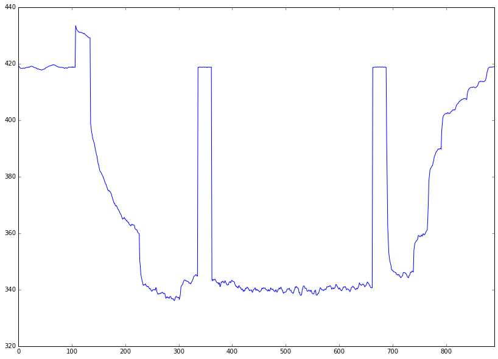

```python
data2['12CO2'].plot()
```

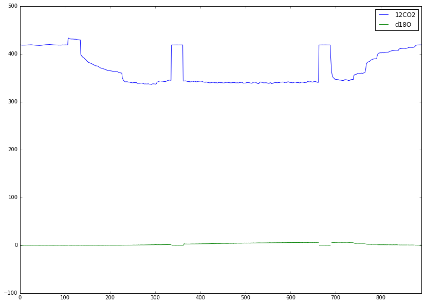

```python
data2[['12CO2','d18O']].plot()
```

```python
import os

path_CO2='/Users/paulgauthier/Documents/Postdoc/Princeton/Experiments/Abisko/2015/Birch 21 LRC/Tree2/CO2/'
#import data from Picarro CO2 analyzer
Data_CO2=pd.DataFrame()
for FileCO2 in os.listdir(path_CO2):
    if FileCO2.endswith(".dat"):
        df=pd.read_csv('%s%s'%(path_CO2,FileCO2),delimiter='\s*',parse_dates={'time':[0, 1]}, index_col=0)
        Data_CO2=pd.concat([Data_CO2,df])
Data_CO2.index = Data_CO2.index.tz_localize('UTC').tz_convert('Europe/Stockholm')
```

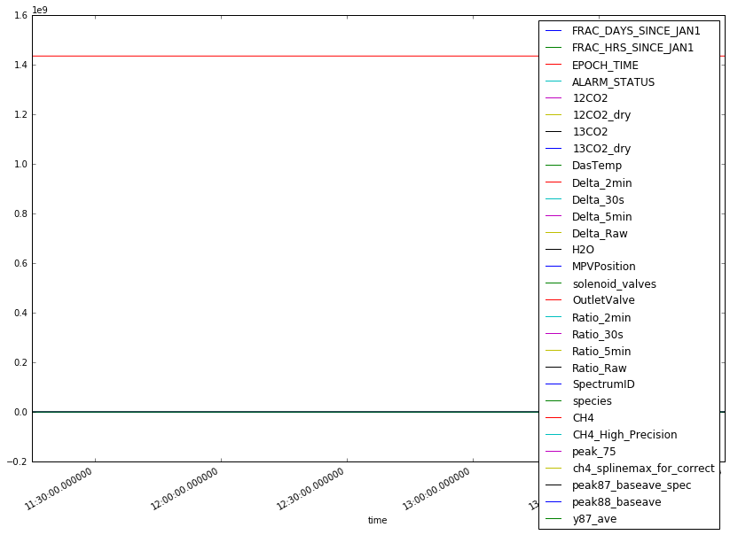

```python
Data_CO2['06/28/2015 11:15:00':'06/28/2015 14:00:00'].plot()
```

```python
Data_CO2.resample('h')
```

| time | FRAC_DAYS_SINCE_JAN1 | FRAC_HRS_SINCE_JAN1 | EPOCH_TIME | ALARM_STATUS | 12CO2 | 12CO2_dry | 13CO2 | 13CO2_dry | DasTemp | Delta_2min | ... | Ratio_Raw | SpectrumID | species | CH4 | CH4_High_Precision | peak_75 | ch4_splinemax_for_correct | peak87_baseave_spec | peak88_baseave | y87_ave |
| --- | --- | --- | --- | --- | --- | --- | --- | --- | --- | --- | --- | --- | --- | --- | --- | --- | --- | --- | --- | --- | --- |
| 2015-06-28 08:00:00+02:00 | 178.083041 | 4273.992989 | 1.435475e+09 | 0 | 354.681079 | 354.838393 | 3.989251 | 3.991018 | 31.959196 | -10.472004 | ... | 0.011132 | 69.037736 | 69.037736 | 1.932809 | 1.966912 | 3.130568 | 418.024452 | 213.393546 | 6.276824 | 1.617180 |
| 2015-06-28 09:00:00+02:00 | 178.104177 | 4274.500246 | 1.435477e+09 | 0 | 354.557477 | 354.633758 | 3.983330 | 3.984186 | 35.286123 | -10.582588 | ... | 0.011119 | 69.289144 | 69.289144 | 1.945364 | 1.962726 | 1.519346 | 420.734345 | 213.319306 | 6.266957 | 1.619013 |
| 2015-06-28 10:00:00+02:00 | 178.145843 | 4275.500227 | 1.435480e+09 | 0 | 354.461236 | 354.515766 | 3.981341 | 3.981953 | 37.288145 | -10.842845 | ... | 0.011117 | 69.263679 | 69.263679 | 1.948390 | 1.962604 | 1.086621 | 421.391102 | 213.261500 | 6.263678 | 1.617159 |
| 2015-06-28 11:00:00+02:00 | 178.190993 | 4276.583827 | 1.435484e+09 | 0 | 346.773920 | 348.533919 | 3.897910 | 3.917671 | 37.456700 | -10.159077 | ... | 0.011125 | 69.346340 | 69.346340 | 1.910099 | 1.955349 | 35.749419 | 413.103724 | 208.576092 | 6.144904 | 1.621029 |
| 2015-06-28 12:00:00+02:00 | 178.229150 | 4277.499606 | 1.435487e+09 | 0 | 337.708018 | 341.016531 | 3.800406 | 3.837573 | 37.599081 | -9.043993 | ... | 0.011137 | 69.328817 | 69.328817 | 1.880917 | 1.948462 | 67.556190 | 406.791294 | 203.198847 | 6.003006 | 1.625134 |
| 2015-06-28 13:00:00+02:00 | 178.270840 | 4278.500151 | 1.435491e+09 | 0 | 340.216384 | 342.951862 | 3.826427 | 3.857140 | 38.468128 | -9.577167 | ... | 0.011131 | 69.309300 | 69.309300 | 1.895632 | 1.950841 | 55.696546 | 409.976518 | 204.705472 | 6.039705 | 1.623359 |
| 2015-06-28 14:00:00+02:00 | 178.312492 | 4279.499801 | 1.435495e+09 | 0 | 348.730410 | 350.995148 | 3.919933 | 3.945344 | 38.664205 | -10.076467 | ... | 0.011125 | 69.310264 | 69.310264 | 1.903498 | 1.950314 | 44.752500 | 411.678182 | 209.819336 | 6.183075 | 1.621877 |
| 2015-06-28 15:00:00+02:00 | 178.354156 | 4280.499752 | 1.435498e+09 | 0 | 348.291810 | 350.145617 | 3.915333 | 3.936137 | 38.514838 | -10.027613 | ... | 0.011126 | 69.325496 | 69.325496 | 1.916089 | 1.954348 | 37.044336 | 414.402795 | 209.555895 | 6.172964 | 1.621105 |
| 2015-06-28 16:00:00+02:00 | 178.395842 | 4281.500203 | 1.435502e+09 | 0 | 351.174042 | 352.888734 | 3.947709 | 3.966951 | 38.252418 | -9.993749 | ... | 0.011126 | 69.316119 | 69.316119 | 1.918467 | 1.955705 | 33.831267 | 414.916272 | 211.287079 | 6.222798 | 1.620659 |
| 2015-06-28 17:00:00+02:00 | 178.437508 | 4282.500184 | 1.435505e+09 | 0 | 350.959406 | 352.454287 | 3.944746 | 3.961520 | 38.139087 | -10.167798 | ... | 0.011124 | 69.297473 | 69.297473 | 1.922746 | 1.956214 | 29.777047 | 415.842504 | 211.158160 | 6.216604 | 1.619385 |
| 2015-06-28 18:00:00+02:00 | 178.479168 | 4283.500030 | 1.435509e+09 | 0 | 351.475990 | 352.885610 | 3.949892 | 3.965706 | 37.840492 | -10.310525 | ... | 0.011123 | 69.325351 | 69.325351 | 1.924654 | 1.956527 | 28.054607 | 416.255748 | 211.468441 | 6.224074 | 1.619080 |
| 2015-06-28 19:00:00+02:00 | 178.520828 | 4284.499861 | 1.435513e+09 | 0 | 352.729023 | 354.104471 | 3.964874 | 3.980308 | 38.681413 | -10.088620 | ... | 0.011125 | 69.310219 | 69.310219 | 1.926524 | 1.956731 | 27.285120 | 416.660722 | 212.221063 | 6.247383 | 1.619078 |
| 2015-06-28 20:00:00+02:00 | 178.562507 | 4285.500158 | 1.435516e+09 | 0 | 353.446400 | 354.819738 | 3.972754 | 3.988165 | 39.071983 | -10.153998 | ... | 0.011124 | 69.282285 | 69.282285 | 1.927205 | 1.956750 | 27.188827 | 416.807560 | 212.651948 | 6.259758 | 1.618913 |
| 2015-06-28 21:00:00+02:00 | 178.604173 | 4286.500154 | 1.435520e+09 | 0 | 355.698617 | 357.079818 | 3.997816 | 4.013314 | 39.522170 | -10.192231 | ... | 0.011124 | 69.353309 | 69.353309 | 1.926136 | 1.956688 | 27.171861 | 416.576477 | 214.004720 | 6.299205 | 1.619345 |
| 2015-06-28 22:00:00+02:00 | 178.641658 | 4287.399790 | 1.435523e+09 | 0 | 365.920879 | 367.039892 | 4.109502 | 4.122042 | 39.784774 | -10.770319 | ... | 0.011117 | 69.288787 | 69.288787 | 1.930821 | 1.955034 | 20.357914 | 417.591087 | 220.144619 | 6.472683 | 1.618369 |

15 rows × 30 columns

[output not shown]

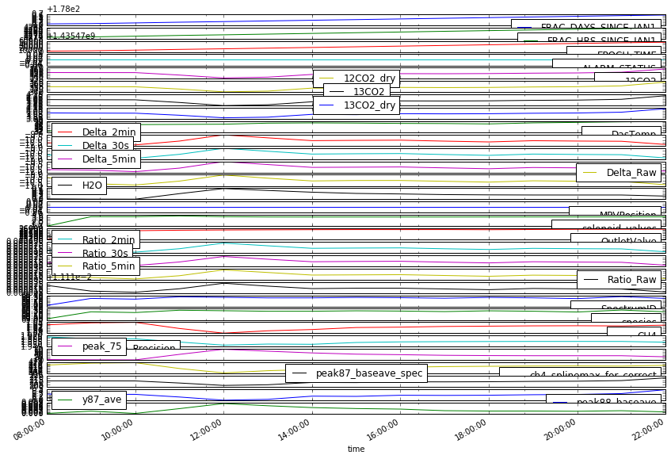

```python
Data_CO2.resample('h').plot(subplots=True)
```

```python
Data_CO2.resample('h',how='mean')
```

| time | FRAC_DAYS_SINCE_JAN1 | FRAC_HRS_SINCE_JAN1 | EPOCH_TIME | ALARM_STATUS | 12CO2 | 12CO2_dry | 13CO2 | 13CO2_dry | DasTemp | Delta_2min | ... | Ratio_Raw | SpectrumID | species | CH4 | CH4_High_Precision | peak_75 | ch4_splinemax_for_correct | peak87_baseave_spec | peak88_baseave | y87_ave |
| --- | --- | --- | --- | --- | --- | --- | --- | --- | --- | --- | --- | --- | --- | --- | --- | --- | --- | --- | --- | --- | --- |
| 2015-06-28 08:00:00+02:00 | 178.083041 | 4273.992989 | 1.435475e+09 | 0 | 354.681079 | 354.838393 | 3.989251 | 3.991018 | 31.959196 | -10.472004 | ... | 0.011132 | 69.037736 | 69.037736 | 1.932809 | 1.966912 | 3.130568 | 418.024452 | 213.393546 | 6.276824 | 1.617180 |
| 2015-06-28 09:00:00+02:00 | 178.104177 | 4274.500246 | 1.435477e+09 | 0 | 354.557477 | 354.633758 | 3.983330 | 3.984186 | 35.286123 | -10.582588 | ... | 0.011119 | 69.289144 | 69.289144 | 1.945364 | 1.962726 | 1.519346 | 420.734345 | 213.319306 | 6.266957 | 1.619013 |
| 2015-06-28 10:00:00+02:00 | 178.145843 | 4275.500227 | 1.435480e+09 | 0 | 354.461236 | 354.515766 | 3.981341 | 3.981953 | 37.288145 | -10.842845 | ... | 0.011117 | 69.263679 | 69.263679 | 1.948390 | 1.962604 | 1.086621 | 421.391102 | 213.261500 | 6.263678 | 1.617159 |
| 2015-06-28 11:00:00+02:00 | 178.190993 | 4276.583827 | 1.435484e+09 | 0 | 346.773920 | 348.533919 | 3.897910 | 3.917671 | 37.456700 | -10.159077 | ... | 0.011125 | 69.346340 | 69.346340 | 1.910099 | 1.955349 | 35.749419 | 413.103724 | 208.576092 | 6.144904 | 1.621029 |
| 2015-06-28 12:00:00+02:00 | 178.229150 | 4277.499606 | 1.435487e+09 | 0 | 337.708018 | 341.016531 | 3.800406 | 3.837573 | 37.599081 | -9.043993 | ... | 0.011137 | 69.328817 | 69.328817 | 1.880917 | 1.948462 | 67.556190 | 406.791294 | 203.198847 | 6.003006 | 1.625134 |
| 2015-06-28 13:00:00+02:00 | 178.270840 | 4278.500151 | 1.435491e+09 | 0 | 340.216384 | 342.951862 | 3.826427 | 3.857140 | 38.468128 | -9.577167 | ... | 0.011131 | 69.309300 | 69.309300 | 1.895632 | 1.950841 | 55.696546 | 409.976518 | 204.705472 | 6.039705 | 1.623359 |
| 2015-06-28 14:00:00+02:00 | 178.312492 | 4279.499801 | 1.435495e+09 | 0 | 348.730410 | 350.995148 | 3.919933 | 3.945344 | 38.664205 | -10.076467 | ... | 0.011125 | 69.310264 | 69.310264 | 1.903498 | 1.950314 | 44.752500 | 411.678182 | 209.819336 | 6.183075 | 1.621877 |
| 2015-06-28 15:00:00+02:00 | 178.354156 | 4280.499752 | 1.435498e+09 | 0 | 348.291810 | 350.145617 | 3.915333 | 3.936137 | 38.514838 | -10.027613 | ... | 0.011126 | 69.325496 | 69.325496 | 1.916089 | 1.954348 | 37.044336 | 414.402795 | 209.555895 | 6.172964 | 1.621105 |
| 2015-06-28 16:00:00+02:00 | 178.395842 | 4281.500203 | 1.435502e+09 | 0 | 351.174042 | 352.888734 | 3.947709 | 3.966951 | 38.252418 | -9.993749 | ... | 0.011126 | 69.316119 | 69.316119 | 1.918467 | 1.955705 | 33.831267 | 414.916272 | 211.287079 | 6.222798 | 1.620659 |
| 2015-06-28 17:00:00+02:00 | 178.437508 | 4282.500184 | 1.435505e+09 | 0 | 350.959406 | 352.454287 | 3.944746 | 3.961520 | 38.139087 | -10.167798 | ... | 0.011124 | 69.297473 | 69.297473 | 1.922746 | 1.956214 | 29.777047 | 415.842504 | 211.158160 | 6.216604 | 1.619385 |
| 2015-06-28 18:00:00+02:00 | 178.479168 | 4283.500030 | 1.435509e+09 | 0 | 351.475990 | 352.885610 | 3.949892 | 3.965706 | 37.840492 | -10.310525 | ... | 0.011123 | 69.325351 | 69.325351 | 1.924654 | 1.956527 | 28.054607 | 416.255748 | 211.468441 | 6.224074 | 1.619080 |
| 2015-06-28 19:00:00+02:00 | 178.520828 | 4284.499861 | 1.435513e+09 | 0 | 352.729023 | 354.104471 | 3.964874 | 3.980308 | 38.681413 | -10.088620 | ... | 0.011125 | 69.310219 | 69.310219 | 1.926524 | 1.956731 | 27.285120 | 416.660722 | 212.221063 | 6.247383 | 1.619078 |
| 2015-06-28 20:00:00+02:00 | 178.562507 | 4285.500158 | 1.435516e+09 | 0 | 353.446400 | 354.819738 | 3.972754 | 3.988165 | 39.071983 | -10.153998 | ... | 0.011124 | 69.282285 | 69.282285 | 1.927205 | 1.956750 | 27.188827 | 416.807560 | 212.651948 | 6.259758 | 1.618913 |
| 2015-06-28 21:00:00+02:00 | 178.604173 | 4286.500154 | 1.435520e+09 | 0 | 355.698617 | 357.079818 | 3.997816 | 4.013314 | 39.522170 | -10.192231 | ... | 0.011124 | 69.353309 | 69.353309 | 1.926136 | 1.956688 | 27.171861 | 416.576477 | 214.004720 | 6.299205 | 1.619345 |
| 2015-06-28 22:00:00+02:00 | 178.641658 | 4287.399790 | 1.435523e+09 | 0 | 365.920879 | 367.039892 | 4.109502 | 4.122042 | 39.784774 | -10.770319 | ... | 0.011117 | 69.288787 | 69.288787 | 1.930821 | 1.955034 | 20.357914 | 417.591087 | 220.144619 | 6.472683 | 1.618369 |

15 rows × 30 columns

```
array([<matplotlib.axes._subplots.AxesSubplot object at 0x10caa8e90>], dtype=object)
```

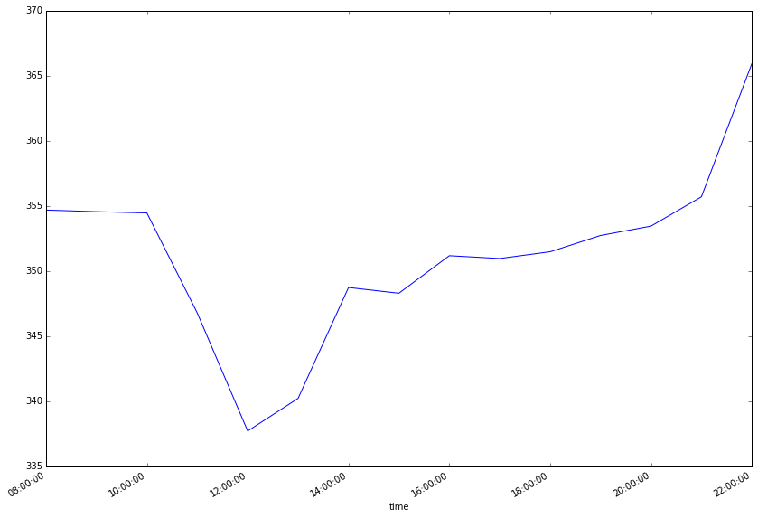

```python
Data_CO2.resample('h',how='mean')['12CO2'].plot(subplots=True)
```